# Practical Machine Learning new

priya malhotra

May 8, 2019

## Introduction

Using devices such as Jawbone Up, Nike FuelBand, and Fitbit it is now possible to collect a large amount of data about personal activity relatively inexpensively. These type of devices are part of the quantified self movement - a group of enthusiasts who take measurements about themselves regularly to improve their health, to find patterns in their behavior, or because they are tech geeks. One thing that people regularly do is quantify how much of a particular activity they do, but they rarely quantify how well they do it. In this project, your goal will be to use data from accelerometers on the belt, forearm, arm, and dumbell of 6 participants. They were asked to perform barbell lifts correctly and incorrectly in 5 different ways. More information is available from the website here: http://web.archive.org/web/20161224072740/http:/groupware.les.inf.puc-rio.br/har (see the section on the Weight Lifting Exercise Dataset).

## Data

```r
library(lubridate)
library(caret)
library(rpart)
```

```r
library(rpart.plot)
library(rattle)
library(randomForest)
library(gbm)
train_in<- read.csv("C:/Users/ashishma/Downloads/pml-training.csv")
dim(train_in)
```

```
## [1] 19622   160
```

```r
test_in<-read.csv("C:/Users/ashishma/Downloads/pml-testing.csv")
dim(test_in)
```

```
## [1]  20 160
```

So there are 19622 observations and 160 variables in training set and 20 observations and 160 variables in testing set.

## Clean data

In order to clean the data we will remove missing values , if we see data there are few columns which have most observations as NA we can remove these columns.

```r
train_clean<-train_in[ ,colSums(is.na(train_in)) == 0]
dim(train_clean)
```

```
## [1] 19622    93
```

```r
test_clean<- test_in[ ,colSums(is.na(test_in)) == 0]
dim(test_clean)
```

```
## [1] 20 60
```

First seven columns are also not of much use so we can remove them.

```r
train_clean<- train_clean[ , -c(1:7)]
dim(train_clean)
```

```
## [1] 19622    86
```

```r
test_clean<- test_clean[ , -c(1:7)]
dim(test_clean)
```

```
## [1] 20 53
```

## Preparing Data For Prediction

```r
set.seed(12345)
inTrain<-createDataPartition(train_clean$classe, p = 0.7, list = FALSE)
trainData<-train_clean[inTrain , ]
testData<-train_clean[-inTrain , ]
dim(trainData)
```

```
## [1] 13737    86
```

```r
dim(testData)
```

```
## [1] 5885   86
```

We can remove the variables that are near zero variance

```r
NZV <- nearZeroVar(trainData)
trainData <- trainData[, -NZV]
testData  <- testData[, -NZV]
dim(trainData)
```

```
## [1] 13737    53
```

```r
dim(testData)
```

```
## [1] 5885   53
```

## Model Building

We will predict outome for our model by using 3 different techniques:

Classification Trees

Random Forest

Generalized Boosted Models

## Prediction with Classification Trees

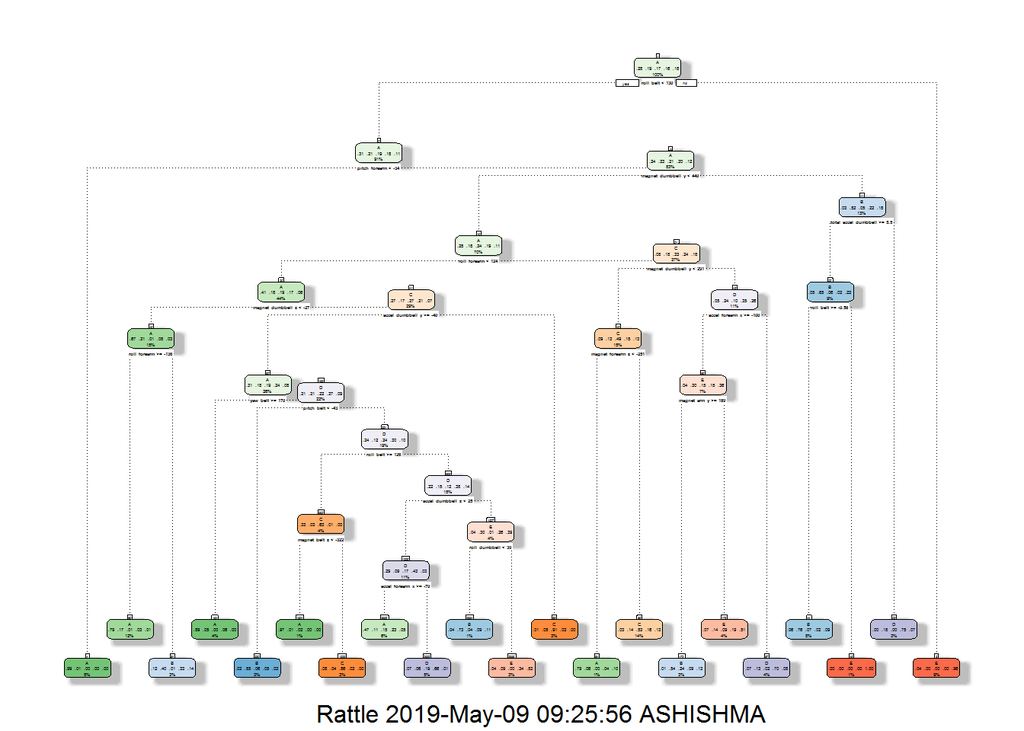

```r
set.seed(12345)
model_tree<-rpart(classe ~ . , data = trainData, method = "class")
fancyRpartPlot(model_tree)
```

Now using this model we will see how this is performing on our Test Data .

```r
predict_model_tree<- predict(model_tree, testData, type = "class")
cm_tree<- confusionMatrix(predict_model_tree, testData$classe )
cm_tree$table
```

```
##           Reference
## Prediction    A    B    C    D    E
##          A 1498  196   69  106   25
##          B   42  669   85   86   92
##          C   43  136  739  129  131
##          D   33   85   98  553   44
##          E   58   53   35   90  790
```

```r
cm_tree$overall[1]
```

```
##  Accuracy
## 0.7220051
```

So we can see the above model gives accuracy of 0.7220051 which gives us out-of-sample-error about .28 .

## Prediction with Random Forest

```r
model_rf<- randomForest(classe ~ . , data = testData)
print(model_rf)
```

```
##
## Call:
##  randomForest(formula = classe ~ ., data = testData)
##                Type of random forest: classification
##                      Number of trees: 500
## No. of variables tried at each split: 7
##
##         OOB estimate of  error rate: 1.7%
## Confusion matrix:
##      A    B    C   D    E class.error
## A 1669    5    0   0    0 0.002986858
## B   25 1100   13   1    0 0.034240562
## C    0   16 1008   2    0 0.017543860
## D    0    0   26 936    2 0.029045643
## E    0    1    3   6 1072 0.009242144
```

Now using this model we will see how this is performing on our Test Data .

```r
predict_model_rf<- predict(model_rf, testData, type = "class")
cm_rf<-confusionMatrix(predict_model_rf,testData$classe)
cm_rf$table
```

```
##           Reference
## Prediction    A    B    C    D    E
##          A 1674    0    0    0    0
##          B    0 1139    0    0    0
##          C    0    0 1026    0    0
##          D    0    0    0  964    0
##          E    0    0    0    0 1082
```

```r
cm_rf$overall[1]
```

```
## Accuracy
##        1
```

## Prediction with Gradient Boosting Machine

```r
model_gbm<- train(classe ~ . , data = trainData, method = "gbm", trControl = trainControl(method = "repeatedcv", number = 5, repeats = 1), verbose = FALSE)
print(model_gbm)
```

```
## Stochastic Gradient Boosting
##
## 13737 samples
##    52 predictor
##     5 classes: 'A', 'B', 'C', 'D', 'E'
##
## No pre-processing
## Resampling: Cross-Validated (5 fold, repeated 1 times)
## Summary of sample sizes: 10989, 10990, 10990, 10989, 10990
## Resampling results across tuning parameters:
##
##   interaction.depth  n.trees  Accuracy   Kappa
##   1                   50      0.7572970  0.6921642
##   1                  100      0.8255803  0.7792114
##   1                  150      0.8566640  0.8185488
##   2                   50      0.8565919  0.8183136
##   2                  100      0.9050737  0.8798732
##   2                  150      0.9315712  0.9134018
##   3                   50      0.8971386  0.8697786
##   3                  100      0.9431460  0.9280516
##   3                  150      0.9615636  0.9513656
##
## Tuning parameter 'shrinkage' was held constant at a value of 0.1
##
## Tuning parameter 'n.minobsinnode' was held constant at a value of 10
## Accuracy was used to select the optimal model using the largest value.
## The final values used for the model were n.trees = 150,
##  interaction.depth = 3, shrinkage = 0.1 and n.minobsinnode = 10.
```

Now using this model we will see how this is performing on our Test Data .

```r
predict_model_gbm<- predict(model_gbm, testData)
cm_gbm<-confusionMatrix(predict_model_gbm,testData$classe)
cm_gbm$table
```

```
##           Reference
## Prediction    A    B    C    D    E
##          A 1647   38    0    2    2
##          B   16 1066   41    3   15
##          C    6   32  963   36    7
##          D    5    3   20  917   22
##          E    0    0    2    6 1036
```

```r
cm_gbm$overall[1]
```

```
##  Accuracy
## 0.9564996
```

So we can see the above model gives accuracy of 0.9564996 which gives us out-of-sample-error about .05 .

## Conclusion

```r
Result<- predict(model_rf, test_clean)
Result
```

```
##  1  2  3  4  5  6  7  8  9 10 11 12 13 14 15 16 17 18 19 20
##  B  A  B  A  A  E  D  B  A  A  B  C  B  A  E  E  A  B  B  B
## Levels: A B C D E
```